# Performance Predictions on Tesla Stock

Jeffrey Hunt, Anmoldeep Sandhu, Kayla Zantello

2022-09-13

## Problem Statement

The main task of this assignment is to download the stock data of company from Yahoo website, and using that data, we need to predict the company future performance using the linear model in R.

Multiple Linear regression Equation:
$$y
= \beta_0 + \beta_1 x_1+ \beta_2 x_2 + ...+ \beta_p x_p$$

### Data setup and exploration

We chooses a Tesla Stock data. We are going to predict the future of Tesla Stock. data source: https://finance.yahoo.com/quote/TSLA/history?p=TSLA

```r
tesla <- read.csv("TSLA.CSV")
tesla.df <- data.frame(tesla)
head(tesla.df)
```

```
##         Date     Open     High      Low    Close Adj.Close   Volume
## 1 2021-09-17 252.3833 253.6800 250.0000 253.1633  253.1633 84612600
## 2 2021-09-20 244.8533 247.3333 239.5400 243.3900  243.3900 74273100
## 3 2021-09-21 244.9300 248.2467 243.4800 246.4600  246.4600 48992100
## 4 2021-09-22 247.8433 251.2233 246.3733 250.6467  250.6467 45378900
## 5 2021-09-23 251.6667 252.7333 249.3067 251.2133  251.2133 35842500
## 6 2021-09-24 248.6300 258.2667 248.1867 258.1300  258.1300 64119000
```

```r
tail(tesla.df)
```

```
##           Date   Open   High    Low  Close Adj.Close   Volume
## 247 2022-09-09 291.67 299.85 291.25 299.68    299.68 54338100
## 248 2022-09-12 300.72 305.49 300.40 304.42    304.42 48674600
## 249 2022-09-13 292.90 297.40 290.40 292.13    292.13 68229600
## 250 2022-09-14 292.24 306.00 291.64 302.61    302.61 72628700
## 251 2022-09-15 301.83 309.12 300.72 303.75    303.75 64795500
## 252 2022-09-16 299.61 303.71 295.60 303.35    303.35 86949500
```

```r
# The data structure
str(tesla.df)
```

```
## 'data.frame':    252 obs. of  7 variables:
##  $ Date     : chr  "2021-09-17" "2021-09-20" "2021-09-21" "2021-09-22" ...
##  $ Open     : num  252 245 245 248 252 ...
##  $ High     : num  254 247 248 251 253 ...
##  $ Low      : num  250 240 243 246 249 ...
##  $ Close    : num  253 243 246 251 251 ...
##  $ Adj.Close: num  253 243 246 251 251 ...
##  $ Volume   : int  84612600 74273100 48992100 45378900 35842500 64119000 84212100 76144200 62828700 53868000 ...
```

```r
names(tesla.df)
```

```
## [1] "Date"      "Open"      "High"      "Low"       "Close"     "Adj.Close"
## [7] "Volume"
```

```r
class(tesla.df)
```

```
## [1] "data.frame"
```

```r
summary(tesla.df)
```

```
##      Date                Open            High            Low
##  Length:252         Min.   :207.9   Min.   :218.0   Min.   :206.9
##  Class :character   1st Qu.:261.8   1st Qu.:267.3   1st Qu.:256.8
##  Mode  :character   Median :296.8   Median :303.1   Median :287.7
##                     Mean   :298.9   Mean   :306.2   Mean   :291.0
##                     3rd Qu.:335.7   3rd Qu.:345.0   3rd Qu.:327.9
##                     Max.   :411.5   Max.   :414.5   Max.   :405.7
##      Close         Adj.Close         Volume
##  Min.   :209.4   Min.   :209.4   Min.   : 35042700
##  1st Qu.:260.8   1st Qu.:260.8   1st Qu.: 63489300
##  Median :295.2   Median :295.2   Median : 77902650
##  Mean   :298.6   Mean   :298.6   Mean   : 80602369
##  3rd Qu.:336.5   3rd Qu.:336.5   3rd Qu.: 93513375
##  Max.   :410.0   Max.   :410.0   Max.   :188556300
```

```r
# checks for missing values
sum(is.na(tesla.df))
```

```
## [1] 0
```

```r
# Calculate the correlation between all variables
cor(tesla.df[2:7])
```

```
##                  Open       High         Low       Close   Adj.Close
## Open       1.00000000 0.99157300  0.98684998  0.97297468  0.97297468
## High       0.99157300 1.00000000  0.98842304  0.98715841  0.98715841
## Low        0.98684998 0.98842304  1.00000000  0.99047846  0.99047846
## Close      0.97297468 0.98715841  0.99047846  1.00000000  1.00000000
## Adj.Close  0.97297468 0.98715841  0.99047846  1.00000000  1.00000000
## Volume    -0.02922186 0.02680747 -0.08639605 -0.02992719 -0.02992719
##                Volume
## Open      -0.02922186
## High       0.02680747
## Low       -0.08639605
## Close     -0.02992719
## Adj.Close -0.02992719
## Volume     1.00000000
```

## Plot the data

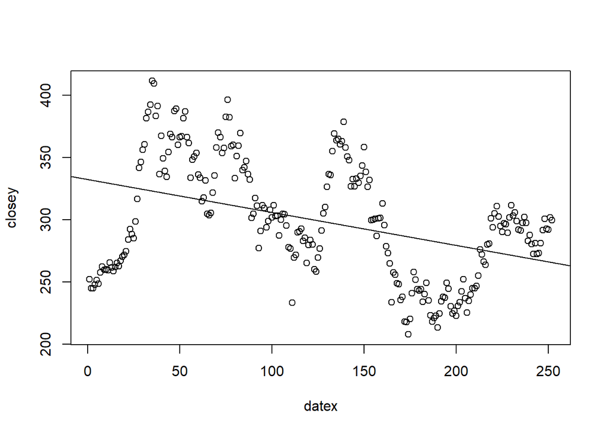

```r
datex <- 1:252
closey <- tesla.df[, 2] #Getting just the closing data since it is our dependent Variable

plot(datex, closey)
abline(lm(closey ~ datex))
```

## Prepare training and testing sets

```r
library(caTools)
set.seed(123)# Reporduce the sample

sample <- sample.split(tesla.df$Close, SplitRatio = 0.8)

tesla.df.train <- subset(tesla.df, sample= True)
tesla.df.test <- subset(tesla.df, sample = False)

head(tesla.df.train)
```

```
##         Date     Open     High      Low    Close Adj.Close   Volume
## 1 2021-09-17 252.3833 253.6800 250.0000 253.1633  253.1633 84612600
## 2 2021-09-20 244.8533 247.3333 239.5400 243.3900  243.3900 74273100
## 3 2021-09-21 244.9300 248.2467 243.4800 246.4600  246.4600 48992100
## 4 2021-09-22 247.8433 251.2233 246.3733 250.6467  250.6467 45378900
## 5 2021-09-23 251.6667 252.7333 249.3067 251.2133  251.2133 35842500
## 6 2021-09-24 248.6300 258.2667 248.1867 258.1300  258.1300 64119000
```

```r
tail(tesla.df.test)
```

```
##           Date   Open   High    Low  Close Adj.Close   Volume
## 247 2022-09-09 291.67 299.85 291.25 299.68    299.68 54338100
## 248 2022-09-12 300.72 305.49 300.40 304.42    304.42 48674600
## 249 2022-09-13 292.90 297.40 290.40 292.13    292.13 68229600
## 250 2022-09-14 292.24 306.00 291.64 302.61    302.61 72628700
## 251 2022-09-15 301.83 309.12 300.72 303.75    303.75 64795500
## 252 2022-09-16 299.61 303.71 295.60 303.35    303.35 86949500
```

## Buld our multiple linear regression model

```r
closeModel <- lm(Close ~., data = tesla.df.train[2:7])
summary(closeModel)
```

```
##
## Call:
## lm(formula = Close ~ ., data = tesla.df.train[2:7])
##
## Residuals:
##        Min         1Q     Median         3Q        Max
## -4.423e-14 -7.100e-17  1.900e-16  3.960e-16  2.857e-15
##
## Coefficients:
##               Estimate Std. Error    t value Pr(>|t|)
## (Intercept)  1.718e-14  1.505e-15  1.141e+01   <2e-16 ***
## Open         4.819e-16  4.326e-17  1.114e+01   <2e-16 ***
## High        -5.599e-16  5.881e-17 -9.521e+00   <2e-16 ***
## Low         -5.554e-16  5.316e-17 -1.045e+01   <2e-16 ***
## Adj.Close    1.000e+00  4.099e-17  2.440e+16   <2e-16 ***
## Volume       1.176e-23  1.103e-23  1.066e+00    0.287
## ---
## Signif. codes:  0 '***' 0.001 '**' 0.01 '*' 0.05 '.' 0.1 ' ' 1
##
## Residual standard error: 2.872e-15 on 246 degrees of freedom
## Multiple R-squared:      1,  Adjusted R-squared:      1
## F-statistic: 1.316e+34 on 5 and 246 DF,  p-value: < 2.2e-16
```

## Improve our Model

```r
#we improve our model only choosing variables with a p value < 2.2e-16
#also we won't include the ADJ Close Model because it the same as the Close Column

closeModel.significantVars <- lm(Close ~ Open + High + Low, data = tesla.df.train)

summary(closeModel.significantVars)
```

```
##
## Call:
## lm(formula = Close ~ Open + High + Low, data = tesla.df.train)
##
## Residuals:
##      Min       1Q   Median       3Q      Max
## -14.9924  -3.1628   0.1633   2.7007  15.3910
##
## Coefficients:
##             Estimate Std. Error t value Pr(>|t|)
## (Intercept)  1.02732    1.83078   0.561    0.575
## Open        -0.68213    0.04917 -13.872   <2e-16 ***
## High         0.81614    0.05157  15.824   <2e-16 ***
## Low          0.86443    0.04348  19.881   <2e-16 ***
## ---
## Signif. codes:  0 '***' 0.001 '**' 0.01 '*' 0.05 '.' 0.1 ' ' 1
##
## Residual standard error: 4.45 on 248 degrees of freedom
## Multiple R-squared:  0.991,  Adjusted R-squared:  0.9908
## F-statistic:  9053 on 3 and 248 DF,  p-value: < 2.2e-16
```

## Regression Output Intepretation

For the example, every time we **Open** we can expect the **Close** to decrease by 0.68 for every dollar amount or for the **Higher** the sell the **close** increases by 0.81.

```r
#Variables used in the model
names(closeModel.significantVars)
```

```
##  [1] "coefficients"  "residuals"     "effects"       "rank"
##  [5] "fitted.values" "assign"        "qr"            "df.residual"
##  [9] "xlevels"       "call"          "terms"         "model"
```

```r
#Get the number of fitted variables in the model
length(closeModel.significantVars$fitted.values)
```

```
## [1] 252
```

## Calculate residuals

Calculating the difference between the predicted and observed values. The residuals values are both positive and negative. If we have a positive residual it means are predicted value was to low, and our negative means are residual were too High.

```r
predicted.train <- closeModel.significantVars$fitted.values
head(predicted.train)
```

```
##        1        2        3        4        5        6
## 252.0145 242.9292 247.0282 249.9714 251.1314 256.7506
```

```r
predicted.train.df <- data.frame(predicted.train)

# Calculate residuals

predicted.train.df.residuals <- closeModel.significantVars$residuals
head(predicted.train.df.residuals)
```

```
##           1           2           3           4           5           6
##  1.14881483  0.46076445 -0.56822515  0.67526320  0.08189894  1.37939856
```

## Make Predictions using the test test

```r
predicted.test <- predict(closeModel.significantVars, newdata = tesla.df.test)
head(predicted.test, 10)
```

```
##        1        2        3        4        5        6        7        8
## 252.0145 242.9292 247.0282 249.9714 251.1314 256.7506 264.2742 259.2568
##        9       10
## 261.6539 261.4369
```

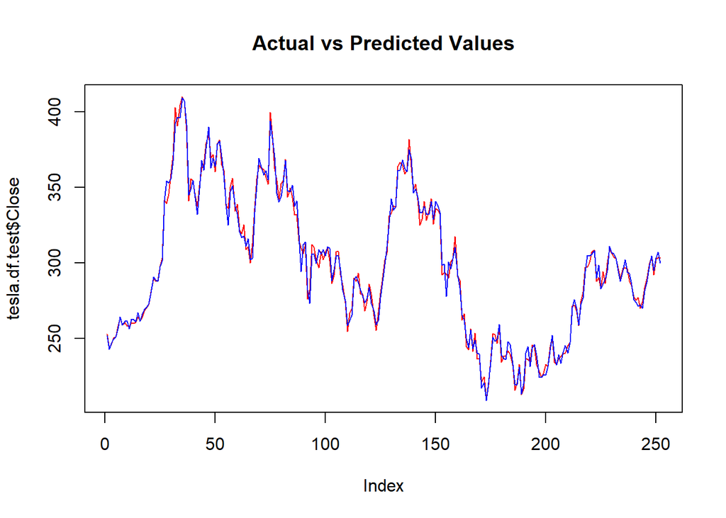

```r
predicted.test.df <- data.frame(predicted.test)

# The actual values vs the predicted values
plot(tesla.df.test$Close, col="red", type="l", lty=1.8, main = "Actual vs Predicted Values")
lines(predicted.test.df, col="blue", type="l", lty=1.4)
```

## Model Verification

### Comfirm Linearity

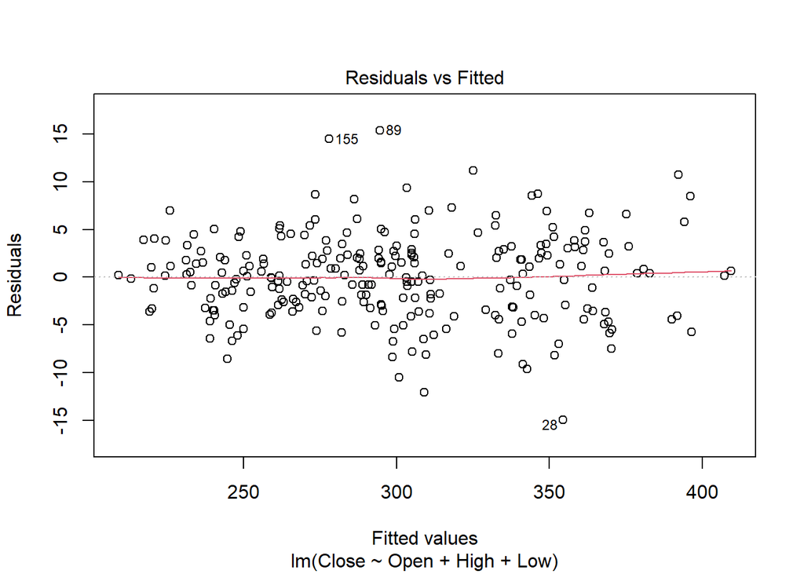

```r
plot(closeModel.significantVars, which = 1)
```

The residuals “bounce randomly” around the 0 line suggesting that the assumption that the relationship is linear.

### Confirm Normality

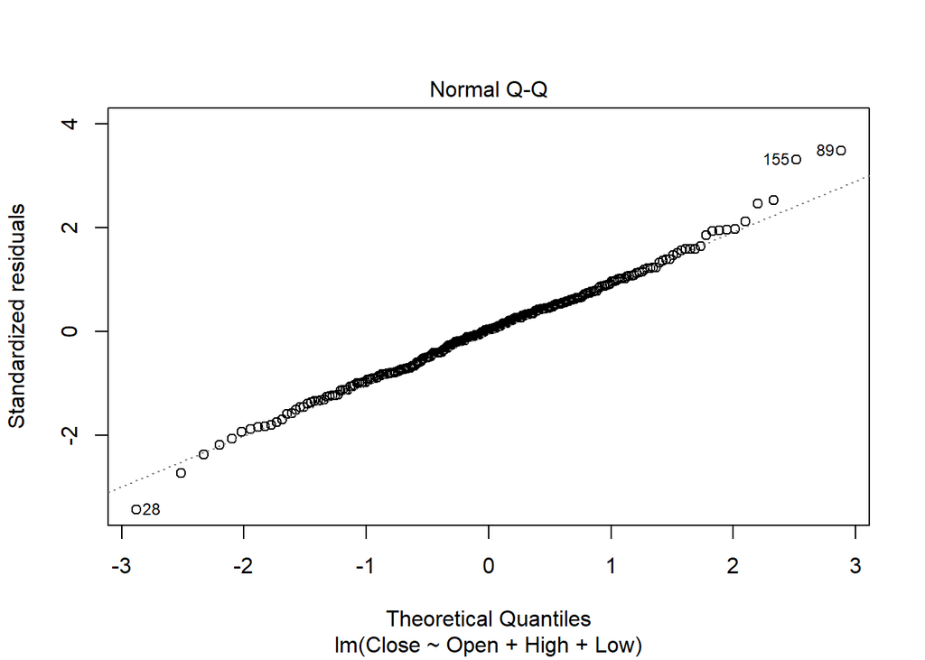

```r
plot(closeModel.significantVars, which = 2)
```

The straight line indicates normal distribution.

### Check Homoscedasticity

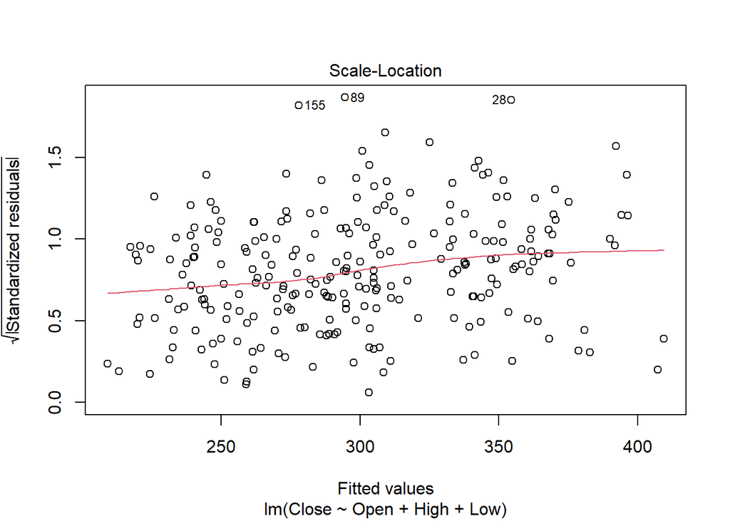

```r
plot(closeModel.significantVars, which = 3)
```

### Verify Outliers

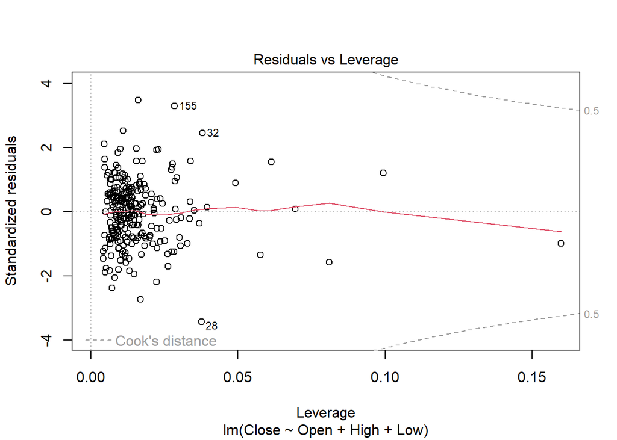

```r
plot(closeModel.significantVars, which = 5)
```

There are 3 outliers (155, 32, 28) but they do not cross the Cook’s distance line indicating they do not significantly inmpact the model.

### Verify Independence

```r
#Verify residuals are independent

library(car)
#test using the durbinwatson test
durbinWatsonTest(closeModel.significantVars)
```

```
##  lag Autocorrelation D-W Statistic p-value
##    1      -0.1113856      2.220284   0.082
##  Alternative hypothesis: rho != 0
```

### Check Homoscedasticity

```r
ncvTest(closeModel.significantVars)
```

```
## Non-constant Variance Score Test
## Variance formula: ~ fitted.values
## Chisquare = 10.17265, Df = 1, p = 0.0014254
```

### Verify Colinearity

```r
vif(closeModel.significantVars)
```

```
##     Open     High      Low
## 67.56769 76.68797 49.26121
```

```r
sqrt(vif(closeModel.significantVars)) > 5
```

```
## Open High  Low
## TRUE TRUE TRUE
```

### Final Close Cost prediction results

Since all tests return true we can we can confirm that there is co linearity. This means that the variables are highly correlated to each other.

```r
predicted.test <- predict(closeModel.significantVars, newdata = tesla.df.test)
predicted.test.df <- data.frame(predicted.test)
head(predicted.test.df[order(predicted.test.df$predicted.test),], 20)
```

```
##  [1] 209.1393 213.2598 217.3803 219.3414 219.8755 220.0737 220.7804 220.9242
##  [9] 224.3427 224.6055 226.0531 226.0905 231.2426 231.4284 231.6999 232.5651
## [17] 233.1001 233.8139 234.4949 236.1789
```

### Our Equation

$$y = 1.03 - 0.68 x_1+ 0.81 x_2 + 0.86
x_3$$

## Christian Worldview:

From a Christian Worldview some other factors that would go to an investment decision process is not only looking at the finances of the company but also the ethics of the company. We should look at this more from a qualitative assessment separate from our statistical model because we want would want to know if this company is trustworthy in investing.

## References:

https://finance.yahoo.com/quote/TSLA/history?p=TSLA https://padlet.com/isac_artzi/uamseybcuinw6t8s https://statsandr.com/blog/multiple-linear-regression-made-simple/#another-interpretation-of-the-intercept